# Toxic Comment Filter

- Show All Code
- Hide All Code
- View Source

BiLSTM model for multi-label classification

code

Deep Learning

Python

R

Author

Simone Brazzi

Published

August 12, 2024

# 1 Introduction

Build a model that can filter user comments based on the degree of language maliciousness:

- Preprocess the text by eliminating the set of tokens that do not make significant contribution at the semantic level.
- Transform the text corpus into sequences.
- Build a Deep Learning model including recurrent layers for a multilabel classification task.
- At prediction time, the model should return a vector containing a 1 or a 0 at each label in the dataset (toxic, severe_toxic, obscene, threat, insult, identity_hate). In this way, a non-harmful comment will be classified by a vector of only 0s [0,0,0,0,0]. In contrast, a dangerous comment will exhibit at least a 1 among the 6 labels.

# 2 Setup

Leveraging Quarto and RStudio, I will setup an R and Python enviroment.

## 2.1 Import R libraries

Import R libraries. These will be used for both the rendering of the document and data analysis. The reason is I prefer `ggplot2` over `matplotlib`. I will also use colorblind safe palettes.

```r
library(tidyverse, verbose = FALSE)
library(tidymodels, verbose = FALSE)
library(reticulate)
library(ggplot2)
library(plotly)
library(RColorBrewer)
library(bslib)
library(Metrics)
library(gt)


Sys.setenv(RETICULATE_PYTHON = "~/R/blog/posts/toxic_comment_filter/.venv/bin/python")
```

## 2.2 Import Python packages

```python
import pandas as pd
import numpy as np
import matplotlib.pyplot as plt
import tensorflow as tf
import keras
import keras_nlp

from keras.backend import clear_session
from keras.models import Model, load_model
from keras.layers import TextVectorization, Input, Dense, Embedding, Dropout, GlobalAveragePooling1D, LSTM, Bidirectional, GlobalMaxPool1D, Flatten, Attention, LayerNormalization
from keras.metrics import Precision, Recall, AUC, SensitivityAtSpecificity, SpecificityAtSensitivity, F1Score

from sklearn.model_selection import train_test_split, KFold
from sklearn.metrics import multilabel_confusion_matrix, classification_report, ConfusionMatrixDisplay, precision_recall_curve, f1_score, recall_score, roc_auc_score
```

```python
print("Num GPUs Available: ", len(tf.config.list_physical_devices('GPU')))
```

```
Num GPUs Available:  1
```

Create a Config class to store all the useful parameters for the model and for the project.

## 2.3 Class Config

I created a `class` with all the basic configuration of the model, to improve the readability.

```python
class Config():
    def __init__(self):
        self.url = "https://s3.eu-west-3.amazonaws.com/profession.ai/datasets/Filter_Toxic_Comments_dataset.csv"
        self.max_tokens = 20000
        self.output_sequence_length = 911 # check the analysis done to establish this value
        self.embedding_dim = 128
        self.batch_size = 32
        self.epochs = 100
        self.temp_split = 0.3
        self.test_split = 0.5
        self.random_state = 42
        self.total_samples = 159571 # total train samples
        self.train_samples = 111699
        self.val_samples = 23936
        self.features = 'comment_text'
        self.labels = ['toxic', 'severe_toxic', 'obscene', 'threat', 'insult', 'identity_hate']
        self.new_labels = ['toxic', 'severe_toxic', 'obscene', 'threat', 'insult', 'identity_hate', "clean"]
        self.label_mapping = {label: i for i, label in enumerate(self.labels)}
        self.new_label_mapping = {label: i for i, label in enumerate(self.labels)}
        self.path = "/Users/simonebrazzi/R/blog/posts/toxic_comment_filter/history/f1score/"
        self.model =  self.path + "model_f1.keras"
        self.checkpoint = self.path + "checkpoint.lstm_model_f1.keras"
        self.history = self.path + "lstm_model_f1.xlsx"

        self.metrics = [
            Precision(name='precision'),
            Recall(name='recall'),
            AUC(name='auc', multi_label=True, num_labels=len(self.labels)),
            F1Score(name="f1", average="macro")

        ]
    def get_early_stopping(self):
        early_stopping = keras.callbacks.EarlyStopping(
            monitor="val_f1", # "val_recall",
            min_delta=0.2,
            patience=10,
            verbose=0,
            mode="max",
            restore_best_weights=True,
            start_from_epoch=3
        )
        return early_stopping

    def get_model_checkpoint(self, filepath):
        model_checkpoint = keras.callbacks.ModelCheckpoint(
            filepath=filepath,
            monitor="val_f1", # "val_recall",
            verbose=0,
            save_best_only=True,
            save_weights_only=False,
            mode="max",
            save_freq="epoch"
        )
        return model_checkpoint

    def find_optimal_threshold_cv(self, ytrue, yproba, metric, thresholds=np.arange(.05, .35, .05), n_splits=7):

      # instantiate KFold
      kf = KFold(n_splits=n_splits, shuffle=True, random_state=42)
      threshold_scores = []

      for threshold in thresholds:

        cv_scores = []
        for train_index, val_index in kf.split(ytrue):

          ytrue_val = ytrue[val_index]
          yproba_val = yproba[val_index]

          ypred_val = (yproba_val >= threshold).astype(int)
          score = metric(ytrue_val, ypred_val, average="macro")
          cv_scores.append(score)

        mean_score = np.mean(cv_scores)
        threshold_scores.append((threshold, mean_score))

        # Find the threshold with the highest mean score
        best_threshold, best_score = max(threshold_scores, key=lambda x: x[1])
      return best_threshold, best_score

config = Config()
```

# 3 Data

The dataset is accessible using `tf.keras.utils.get_file` to get the file from the url. *N.B.* For reproducibility purpose, I also downloaded the dataset. There was time in which the link was not available.

```python
# df = pd.read_csv(config.path)
file = tf.keras.utils.get_file("Filter_Toxic_Comments_dataset.csv", config.url)
df = pd.read_csv(file)
```

```r
library(reticulate)

py$df %>%
  tibble() %>%
  head(5) %>%
  gt() %>%
  tab_header(
    title = "First five observations"
  ) %>%
   cols_align(
    align = "center",
    columns = c("toxic", "severe_toxic", "obscene", "threat", "insult", "identity_hate", "sum_injurious")
  ) %>%
  cols_align(
    align = "left",
    columns = comment_text
  ) %>%
  cols_label(
    comment_text = "Comments",
    toxic = "Toxic",
    severe_toxic = "Severe Toxic",
    obscene = "Obscene",
    threat = "Threat",
    insult = "Insult",
    identity_hate = "Identity Hate",
    sum_injurious = "Sum Injurious"
    )
```

Table 1: First 5 elemtns

First five observations

| Comments | Toxic | Severe Toxic | Obscene | Threat | Insult | Identity Hate | Sum Injurious |
| --- | --- | --- | --- | --- | --- | --- | --- |
| Explanation Why the edits made under my username Hardcore Metallica Fan were reverted? They weren't vandalisms, just closure on some GAs after I voted at New York Dolls FAC. And please don't remove th… | 0 | 0 | 0 | 0 | 0 | 0 | 0 |
| D'aww! He matches this background colour I'm seemingly stuck with. Thanks. (talk) 21:51, January 11, 2016 (UTC) | 0 | 0 | 0 | 0 | 0 | 0 | 0 |
| Hey man, I'm really not trying to edit war. It's just that this guy is constantly removing relevant information and talking to me through edits instead of my talk page. He seems to care more about the… | 0 | 0 | 0 | 0 | 0 | 0 | 0 |
| " More I can't make any real suggestions on improvement - I wondered if the section statistics should be later on, or a subsection of ""types of accidents"" -I think the references may need tidying so… | 0 | 0 | 0 | 0 | 0 | 0 | 0 |
| You, sir, are my hero. Any chance you remember what page that's on? | 0 | 0 | 0 | 0 | 0 | 0 | 0 |

Lets create a *clean* variable for EDA purpose: I want to visually see how many observation are clean vs the others labels.

```python
df.loc[df.sum_injurious == 0, "clean"] = 1
df.loc[df.sum_injurious != 0, "clean"] = 0
```

## 3.1 EDA

First a check on the dataset to find possible missing values and imbalances.

### 3.1.1 Frequency

```r
library(reticulate)
df_r <- py$df
new_labels_r <- py$config$new_labels

df_r_grouped <- df_r %>%
  select(all_of(new_labels_r)) %>%
  pivot_longer(
    cols = all_of(new_labels_r),
    names_to = "label",
    values_to = "value"
  ) %>%
  group_by(label) %>%
  summarise(count = sum(value)) %>%
  mutate(freq = round(count / sum(count), 4))

df_r_grouped %>%
  gt() %>%
  tab_header(
    title = "Labels frequency",
    subtitle = "Absolute and relative frequency"
  ) %>%
  fmt_number(
    columns = "count",
    drop_trailing_zeros = TRUE,
    drop_trailing_dec_mark = TRUE,
    use_seps = TRUE
  ) %>%
  fmt_percent(
    columns = "freq",
    decimals = 2,
    drop_trailing_zeros = TRUE,
    drop_trailing_dec_mark = FALSE
  ) %>%
  cols_align(
    align = "center",
    columns = c("count", "freq")
  ) %>%
  cols_align(
    align = "left",
    columns = label
  ) %>%
  cols_label(
    label = "Label",
    count = "Absolute Frequency",
    freq = "Relative frequency"
  )
```

Table 2: Absolute and relative labels frequency

Labels frequency

Absolute and relative frequency

| Label | Absolute Frequency | Relative frequency |
| --- | --- | --- |
| clean | 143,346 | 80.33% |
| identity_hate | 1,405 | 0.79% |
| insult | 7,877 | 4.41% |
| obscene | 8,449 | 4.73% |
| severe_toxic | 1,595 | 0.89% |
| threat | 478 | 0.27% |
| toxic | 15,294 | 8.57% |

### 3.1.2 Barchart

```r
library(reticulate)
barchart <- df_r_grouped %>%
  ggplot(aes(x = reorder(label, count), y = count, fill = label)) +
  geom_col() +
  labs(
    x = "Labels",
    y = "Count"
  ) +
  # sort bars in descending order
  scale_x_discrete(limits = df_r_grouped$label[order(df_r_grouped$count, decreasing = TRUE)]) +
  scale_fill_brewer(type = "seq", palette = "RdYlBu") +
  theme_minimal()
ggplotly(barchart)
```

[interactive chart not shown]

Figure 1: Imbalance in the dataset with clean variable

It is visible how much the dataset in imbalanced. This means it could be useful to check for the class weight and use this argument during the training.

## 3.2 Sequence lenght definition

To convert the text in a useful input for a NN, it is necessary to use a `TextVectorization layer`. See the Section 4 section.

One of the method is `output_sequence_length`: to better define it, it is useful to analyze our text length. To simulate what the model we do, we are going to remove the punctuation and the new lines from the comments.

### 3.2.1 Summary

```r
library(reticulate)
df_r %>%
  mutate(
    comment_text_clean = comment_text %>%
      tolower() %>%
      str_remove_all("[[:punct:]]") %>%
      str_replace_all("\n", " "),
    text_length = comment_text_clean %>% str_count()
    ) %>%
  pull(text_length) %>%
  summary() %>%
  as.list() %>%
  as_tibble() %>%
  gt() %>%
  tab_header(
    title = "Summary Statistics",
    subtitle = "of text length"
  ) %>%
  fmt_number(
    drop_trailing_zeros = TRUE,
    drop_trailing_dec_mark = TRUE,
    use_seps = TRUE
  ) %>%
  cols_align(
    align = "center",
  ) %>%
  cols_label(
    Min. = "Min",
    `1st Qu.` = "Q1",
    Median = "Median",
    `3rd Qu.` = "Q3",
    Max. = "Max"
  )
```

Table 3: Summary of text length

Summary Statistics

of text length

| Min | Q1 | Median | Mean | Q3 | Max |
| --- | --- | --- | --- | --- | --- |
| 4 | 91 | 196 | 378.4 | 419 | 5,000 |

### 3.2.2 Boxplot

```r
library(reticulate)
boxplot <- df_r %>%
  mutate(
    comment_text_clean = comment_text %>%
      tolower() %>%
      str_remove_all("[[:punct:]]") %>%
      str_replace_all("\n", " "),
    text_length = comment_text_clean %>% str_count()
    ) %>%
  # pull(text_length) %>%
  ggplot(aes(y = text_length)) +
  geom_boxplot() +
  theme_minimal()
ggplotly(boxplot)
```

[interactive chart not shown]

Figure 2: Text length boxplot

### 3.2.3 Histogram

```r
df_ <- df_r %>%
  mutate(
    comment_text_clean = comment_text %>%
      tolower() %>%
      str_remove_all("[[:punct:]]") %>%
      str_replace_all("\n", " "),
    text_length = comment_text_clean %>% str_count()
  )

Q1 <- quantile(df_$text_length, 0.25)
Q3 <- quantile(df_$text_length, 0.75)
IQR <- Q3 - Q1
upper_fence <- as.integer(Q3 + 1.5 * IQR)

histogram <- df_ %>%
  ggplot(aes(x = text_length)) +
  geom_histogram(bins = 50) +
  geom_vline(aes(xintercept = upper_fence), color = "red", linetype = "dashed", linewidth = 1) +
  theme_minimal() +
  xlab("Text Length") +
  ylab("Frequency") +
  xlim(0, max(df_$text_length, upper_fence))
ggplotly(histogram)
```

[interactive chart not shown]

Figure 3: Text length histogram with boxplot upper fence

Considering all the above analysis, I think a good starting value for the `output_sequence_length` is 911, the upper fence of the boxplot. In the last plot, it is the dashed red vertical line.. Doing so, we are removing the outliers, which are a small part of our dataset.

## 3.3 Dataset

Now we can split the dataset in 3: *train*, *test* and *validation* sets. Considering there is not a function in sklearn which lets split in these 3 sets, we can do the following: - split between a *train* and *temp*orary set with a 0.3 split. - split the *temp*orary set in 2 equal sized *test* and *val* sets.

```python
x = df[config.features].values
y = df[config.labels].values

xtrain, xtemp, ytrain, ytemp = train_test_split(
  x,
  y,
  test_size=config.temp_split, # .3
  random_state=config.random_state
  )
xtest, xval, ytest, yval = train_test_split(
  xtemp,
  ytemp,
  test_size=config.test_split, # .5
  random_state=config.random_state
  )
```

The datasets are created using the `tf.data.Dataset` function. It creates a data input pipeline. The `tf.data` API makes it possible to handle large amounts of data, read from different data formats, and perform complex transformations. The `tf.data.Dataset` is an abstraction that represents a sequence of elements, in which each element consists of one or more components. Here each dataset is creates using `from_tensor_slices`. It create a tf.data.Dataset from a tuple (features, labels). `.batch` let us work in batches to improve performance, while `.prefetch` overlaps the preprocessing and model execution of a training step. While the model is executing training step s, the input pipeline is reading the data for step s+1. Check the [documentation](https://www.tensorflow.org/guide/data_performance) for further informations.

```python
train_ds = (
    tf.data.Dataset
    .from_tensor_slices((xtrain, ytrain))
    .shuffle(xtrain.shape[0])
    .batch(config.batch_size)
    .prefetch(tf.data.experimental.AUTOTUNE)
)

test_ds = (
    tf.data.Dataset
    .from_tensor_slices((xtest, ytest))
    .batch(config.batch_size)
    .prefetch(tf.data.experimental.AUTOTUNE)
)

val_ds = (
    tf.data.Dataset
    .from_tensor_slices((xval, yval))
    .batch(config.batch_size)
    .prefetch(tf.data.experimental.AUTOTUNE)
)
```

```python
print(
  f"train_ds cardinality: {train_ds.cardinality()}\n",
  f"val_ds cardinality: {val_ds.cardinality()}\n",
  f"test_ds cardinality: {test_ds.cardinality()}\n"
  )
```

```
train_ds cardinality: 3491
 val_ds cardinality: 748
 test_ds cardinality: 748
```

Check the first element of the dataset to be sure that the preprocessing is done correctly.

```python
train_ds.as_numpy_iterator().next()
```

[output not shown]

[output cut: 38 more lines]

And we check also the shape. We expect a feature of shape (batch, ) and a target of shape (batch, number of labels).

```python
print(
  f"text train shape: {train_ds.as_numpy_iterator().next()[0].shape}\n",
  f" text train type: {train_ds.as_numpy_iterator().next()[0].dtype}\n",
  f"label train shape: {train_ds.as_numpy_iterator().next()[1].shape}\n",
  f"label train type: {train_ds.as_numpy_iterator().next()[1].dtype}\n"
  )
```

```
text train shape: (32,)
  text train type: object
 label train shape: (32, 6)
 label train type: int64
```

# 4 Preprocessing

Of course preprocessing! Text is not the type of input a NN can handle. The *`TextVectorization`* layer is meant to handle natural language inputs. The processing of each example contains the following steps: 1. `Standardize` each example (usually lowercasing + punctuation stripping) 2. `Split` each example into substrings (usually words) 3. Recombine substrings into `tokens` (usually ngrams) 4. `Index` tokens (associate a unique int value with each token) 5. `Transform` each example using this index, either into a vector of ints or a dense float vector.

For more reference, see the documentation at the following [link](https://keras.io/api/layers/preprocessing_layers/text/text_vectorization/).

```python
text_vectorization = TextVectorization(
  max_tokens=config.max_tokens,
  standardize="lower_and_strip_punctuation",
  split="whitespace",
  output_mode="int",
  output_sequence_length=config.output_sequence_length,
  pad_to_max_tokens=True
  )

# prepare a dataset that only yields raw text inputs (no labels)
text_train_ds = train_ds.map(lambda x, y: x)
# adapt the text vectorization layer to the text data to index the dataset vocabulary
text_vectorization.adapt(text_train_ds)
```

This layer is set to: - `max_tokens`: 20000. It is common for text classification. It is the *maximum size* of the vocabulary for this layer. - `output_sequence_length`: 911. See Figure 3 for the reason why. Only valid in `"int"` mode. - `output_mode`: outputs integer indices, one integer index per split string token. When output_mode == “int”, 0 is reserved for masked locations; this reduces the vocab size to max_tokens - 2 instead of max_tokens - 1. - `standardize`: `"lower_and_strip_punctuation"`. - `split`: on whitespace.

To preserve the original comments as text and also have a tf.data.Dataset in which the text is preprocessed by the TextVectorization function, it is possible to map it to the features of each dataset.

```python
processed_train_ds = train_ds.map(
    lambda x, y: (text_vectorization(x), y),
    num_parallel_calls=tf.data.experimental.AUTOTUNE
)
processed_val_ds = val_ds.map(
    lambda x, y: (text_vectorization(x), y),
    num_parallel_calls=tf.data.experimental.AUTOTUNE
)
processed_test_ds = test_ds.map(
    lambda x, y: (text_vectorization(x), y),
    num_parallel_calls=tf.data.experimental.AUTOTUNE
)
```

# 5 Model

## 5.1 Definition

Define the model using the *Functional* API.

```python
def get_deeper_lstm_model():

    clear_session()

    inputs = Input(shape=(None,), dtype=tf.int64, name="inputs")

    embedding = Embedding(
        input_dim=config.max_tokens,
        output_dim=config.embedding_dim,
        mask_zero=True,
        name="embedding"
    )(inputs)
    x = Bidirectional(LSTM(256, return_sequences=True, name="bilstm_1"))(embedding)
    x = Bidirectional(LSTM(128, return_sequences=True, name="bilstm_2"))(x)
    # Global average pooling
    x = GlobalAveragePooling1D()(x)
    # Add regularization
    x = Dropout(0.3)(x)
    x = Dense(64, activation='relu', kernel_regularizer=tf.keras.regularizers.l2(0.01))(x)
    x = LayerNormalization()(x)

    outputs = Dense(len(config.labels), activation='sigmoid', name="outputs")(x)

    model = Model(inputs, outputs)
    model.compile(
      optimizer='adam',
      loss="binary_crossentropy",
      metrics=config.metrics,
      steps_per_execution=32
      )

    return model

lstm_model = get_deeper_lstm_model()
lstm_model.summary()
```

[output not shown]

## 5.2 Callbacks

Finally, the model has been trained using 2 callbacks: - Early Stopping, to avoid to consume the kaggle GPU time. - Model Checkpoint, to retrieve the best model training information.

```python
my_es = config.get_early_stopping()
my_mc = config.get_model_checkpoint(filepath="/checkpoint.keras")
callbacks = [my_es, my_mc]
```

## 5.3 Final preparation before fit

Considering the dataset is imbalanced, to increase the performance we need to calculate the class weight. This will be passed during the training of the model.

```python
lab = pd.DataFrame(columns=config.labels, data=ytrain)
r = lab.sum() / len(ytrain)
class_weight = dict(zip(range(len(config.labels)), r))
df_class_weight = pd.DataFrame.from_dict(
  data=class_weight,
  orient='index',
  columns=['class_weight']
  )
df_class_weight.index = config.labels
```

```r
py$df_class_weight %>%
  gt() %>%
  fmt_percent(
    decimals = 2,
    drop_trailing_zeros = TRUE,
    drop_trailing_dec_mark = TRUE
  )
```

Table 4: Class weight

| class_weight |
| --- |
| 9.59% |
| 0.99% |
| 5.28% |
| 0.31% |
| 4.91% |
| 0.87% |

It is also useful to define the steps per epoch for train and validation dataset. This step is required to avoid to not consume entirely the dataset during the fit, which happened to me.

```python
steps_per_epoch = config.train_samples // config.batch_size
validation_steps = config.val_samples // config.batch_size
```

## 5.4 Fit

The fit has been done on Kaggle to levarage the GPU. Some considerations about the model:

- `.repeat()` ensure the model sees all the dataset.
- `epocs` is set to 100.
- `validation_data` has the same repeat.
- `callbacks` are the one defined before.
- `class_weight` ensure the model is trained using the frequency of each class, because our dataset is imbalanced.
- `steps_per_epoch` and `validation_steps` depend on the use of `repeat`.

```python
history = model.fit(
  processed_train_ds.repeat(),
  epochs=config.epochs,
  validation_data=processed_val_ds.repeat(),
  callbacks=callbacks,
  class_weight=class_weight,
  steps_per_epoch=steps_per_epoch,
  validation_steps=validation_steps
  )
```

Now we can import the model and the history trained on Kaggle.

```python
model = load_model(filepath=config.model)
history = pd.read_excel(config.history)
```

## 5.5 Evaluate

```python
validation = model.evaluate(
  processed_val_ds.repeat(),
  steps=validation_steps, # 748
  verbose=0
  )
```

```r
val_metrics <- tibble(
  metric = c("loss", "precision", "recall", "auc", "f1_score"),
  value = py$validation
  )
val_metrics %>%
  gt() %>%
  fmt_number(
    columns = c("value"),
    decimals = 4,
    drop_trailing_zeros = TRUE,
    drop_trailing_dec_mark = TRUE
  ) %>%
  cols_align(
    align = "left",
    columns = metric
  ) %>%
  cols_align(
    align = "center",
    columns = value
  ) %>%
  cols_label(
    metric = "Metric",
    value = "Value"
  )
```

Table 5: Model validation metric

| Metric | Value |
| --- | --- |
| loss | 0.0635 |
| precision | 0.6866 |
| recall | 0.7063 |
| auc | 0.9507 |
| f1_score | 0.0297 |

## 5.6 Predict

For the prediction, the model does not need to repeat the dataset, because it has already been trained on all of the train data. Now it has just to consume the new data to make the prediction.

```python
predictions = model.predict(processed_test_ds, verbose=0)
```

## 5.7 Confusion Matrix

The best way to assess the performance of a multi label classification is using a confusion matrix. Sklearn has a specific function to create a multi label classification matrix to handle the fact that there could be multiple labels for one prediction.

### 5.7.1 Grid Search Cross Validation for best threshold

Grid Search CV is a technique for fine-tuning hyperparameter of a ML model. It systematically search through a set of hyperparamenter values to find the combination which led to the best model performance. In this case, I am using a `KFold` Cross Validation is a resempling technique to split the data into k consecutive folds. Each fold is used once as a validation while the k - 1 remaining folds are the training set. See the [documentation](https://scikit-learn.org/stable/modules/generated/sklearn.model_selection.KFold.html) for more information.

### 5.7.2 Confidence threshold and Precision-Recall trade off

Whilst the KFold GDCV technique is usefull to test multiple hyperparameter, it is important to understand the problem we are facing. A multi label deep learning classifier outputs a vector of **per-class** probabilities. These need to be converted to a **binary vector** using a **confidence threshold**.

- The higher the threshold, the less classes the model predicts, increasing model confidence [higher Precision] and increasing missed classes [lower Recall].
- The lower the threshold, the more classes the model predicts, decreasing model confidence [lower Precision] and decreasing missed classes [higher Recall].

Threshold selection mean we have to decide which metric to prioritize, based on the problem we are facing and the relative cost of misduging. We can consider the toxic comment filtering a problem similiar to cancer diagnostic. It is better to predict cancer in people who do not have it [False Positive] and perform further analysis than do not predict cancer when the patient has the disease [False Negative].

I decide to train the model on the F1 score to have a balanced model in both precision and recall and leave to the threshold selection to increase the recall performance.

Moreover, the model has been trained on the **macro avarage F1 score**, which is a single performance indicator obtained by the mean of the Precision and Recall scores of **individual classses**.

$$F1\ macro\ avg = \frac{\sum_{i=1}^{n} F1_i}{n}$$

It is useful with **imbalanced** classes, because it weights each classes equally. It is not influenced by the number of samples of each classes. This is sette both in the `config.metrics` and `find_optimal_threshold_cv`.

#### f1_score

```python
ytrue = ytest.astype(int)
y_pred_proba = predictions
optimal_threshold_f1, best_score_f1 = config.find_optimal_threshold_cv(ytrue, y_pred_proba, f1_score)

print(f"Optimal threshold: {optimal_threshold_f1}")
```

```
Optimal threshold: 0.30000000000000004
```

```python
print(f"Best score: {best_score_f1}")
```

```
Best score: 0.5088499203486339
```

```python
# Use the optimal threshold to make predictions
final_predictions_f1 = (y_pred_proba >= optimal_threshold_f1).astype(int)
```

Optimal threshold f1 score: 0.3. Best score: 0.5088499.

#### recall_score

```python
ytrue = ytest.astype(int)
y_pred_proba = predictions
optimal_threshold_recall, best_score_recall = config.find_optimal_threshold_cv(ytrue, y_pred_proba, recall_score)

# Use the optimal threshold to make predictions
final_predictions_recall = (y_pred_proba >= optimal_threshold_recall).astype(int)
```

Optimal threshold recall: 0.05. Best score: 0.7891362.

#### roc_auc_score

```python
ytrue = ytest.astype(int)
y_pred_proba = predictions
optimal_threshold_roc, best_score_roc = config.find_optimal_threshold_cv(ytrue, y_pred_proba, roc_auc_score)

print(f"Optimal threshold: {optimal_threshold_roc}")
```

```
Optimal threshold: 0.05
```

```python
print(f"Best score: {best_score_roc}")
```

```
Best score: 0.8729891504097674
```

```python
# Use the optimal threshold to make predictions
final_predictions_roc = (y_pred_proba >= optimal_threshold_roc).astype(int)
```

Optimal threshold roc: 0.05. Best score: 0.8729892.

### 5.7.3 Confusion Matrix Plot

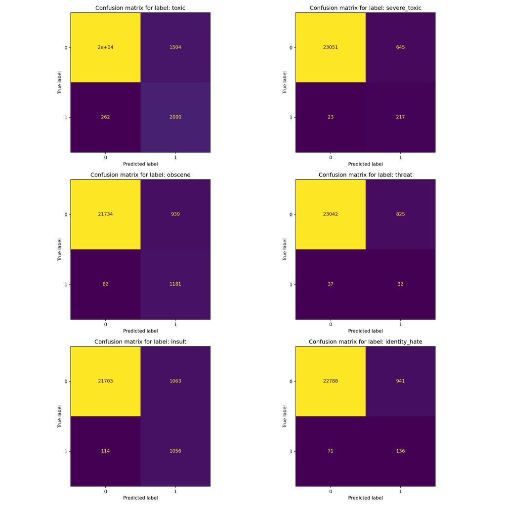

Figure 4: Multi Label Confusion matrix

```python
# convert probability predictions to predictions
ypred = predictions >=  optimal_threshold_recall # .05
ypred = ypred.astype(int)

# create a plot with 3 by 2 subplots
fig, axes = plt.subplots(3, 2, figsize=(15, 15))
axes = axes.flatten()
mcm = multilabel_confusion_matrix(ytrue, ypred)
# plot the confusion matrices for each label
for i, (cm, label) in enumerate(zip(mcm, config.labels)):
    disp = ConfusionMatrixDisplay(confusion_matrix=cm)
    disp.plot(ax=axes[i], colorbar=False)
    axes[i].set_title(f"Confusion matrix for label: {label}")
plt.tight_layout()
plt.show()
```

## 5.8 Classification Report

```python
cr = classification_report(
  ytrue,
  ypred,
  target_names=config.labels,
  digits=4,
  output_dict=True
  )
df_cr = pd.DataFrame.from_dict(cr).reset_index()
```

```r
library(reticulate)
df_cr <- py$df_cr %>% dplyr::rename(names = index)
cols <- df_cr %>% colnames()
df_cr %>%
  pivot_longer(
    cols = -names,
    names_to = "metrics",
    values_to = "values"
  ) %>%
  pivot_wider(
    names_from = names,
    values_from = values
  ) %>%
  gt() %>%
  tab_header(
    title = "Confusion Matrix",
    subtitle = "Threshold optimization favoring recall"
  ) %>%
  fmt_number(
    columns = c("precision", "recall", "f1-score", "support"),
    decimals = 2,
    drop_trailing_zeros = TRUE,
    drop_trailing_dec_mark = FALSE
  ) %>%
  cols_align(
    align = "center",
    columns = c("precision", "recall", "f1-score", "support")
  ) %>%
  cols_align(
    align = "left",
    columns = metrics
  ) %>%
  cols_label(
    metrics = "Metrics",
    precision = "Precision",
    recall = "Recall",
    `f1-score` = "F1-Score",
    support = "Support"
  )
```

Table 6: Classification report

Confusion Matrix

Threshold optimization favoring recall

| Metrics | Precision | Recall | F1-Score | Support |
| --- | --- | --- | --- | --- |
| toxic | 0.57 | 0.88 | 0.69 | 2,262. |
| severe_toxic | 0.25 | 0.9 | 0.39 | 240. |
| obscene | 0.56 | 0.94 | 0.7 | 1,263. |
| threat | 0.04 | 0.46 | 0.07 | 69. |
| insult | 0.5 | 0.9 | 0.64 | 1,170. |
| identity_hate | 0.13 | 0.66 | 0.21 | 207. |
| micro avg | 0.44 | 0.89 | 0.59 | 5,211. |
| macro avg | 0.34 | 0.79 | 0.45 | 5,211. |
| weighted avg | 0.51 | 0.89 | 0.64 | 5,211. |
| samples avg | 0.05 | 0.08 | 0.06 | 5,211. |

# 6 Conclusions

Possibile improvements could be to increase the number of observations, expecially for the threat one. In general there are too many clean comments. This could be avoided doing an undersampling of the clean comment, which I explicitly avoided to check the performance on the BiLSTM with an imbalanced dataset, leveraging the class weight method.